# Determinación de efectos de luz en germinación de *Pisum sativum* L.

Author

Acuña R. E, Grandes C. B, Llaja Z. E, Mondragon H. E, Santillan P. J, Rojas C. G

# 1 Introducción

El origen del guisante (Pisum sativum L.) se encuentra en la región del Mediterráneo, principalmente en el Medio Oriente, donde fue domesticado. Fue una parte esencial de la dieta de los cazadores-recolectores al final de la última Edad de Hielo, tanto en el Medio Oriente como en Europa. Evidencias arqueológicas de los milenios X y IX a.C. indican que los guisantes, junto con otras legumbres como las arvejas y los garbanzos, eran consumidos comúnmente antes de ser cultivados. Esto sugiere que la domesticación de las legumbres, incluidos los guisantes, podría haberse producido antes que la de los cereales, marcando una parte significativa de la revolución agrícola que facilitó el establecimiento de asentamientos permanentes (Ghaleb et al., 2022).

Los esfuerzos de selección y mejora durante siglos han dado lugar al desarrollo de miles de variedades de guisantes, que ahora se mantienen en colecciones de germoplasma en todo el mundo. Los ancestros silvestres del guisante se encuentran en Irán, Turkmenistán y en partes del norte de África y el sur de Europa (Ghaleb et al., 2022).

El cultivo de la arveja (Pisum sativum L.) es fundamental por sus beneficios nutricionales y económicos, especialmente en regiones como el centro y la sierra norte de Ecuador. Su alto contenido proteico (24.1% en grano seco) la convierte en una fuente importante de nutrientes, contribuyendo a la seguridad alimentaria. Además, la arveja mejora la calidad del suelo al fijar nitrógeno, lo que reduce la dependencia de fertilizantes sintéticos y favorece la rotación de cultivos, promoviendo una agricultura más sostenible (Smýkal et al., 2012).

Este cultivo se adapta bien a climas templados y fríos, permitiendo su cultivo a altitudes entre 2,400 y 3,200 metros sobre el nivel del mar. La posibilidad de obtener hasta dos cosechas anuales, especialmente en variedades de cosecha verde, favorece el rendimiento y tiene un impacto positivo en las economías rurales.

La germinación del cultivo es un proceso crucial, ya que marca el comienzo del ciclo de vida de la planta y determina el éxito de su establecimiento. En condiciones óptimas, la germinación permite que las semillas liberen su potencial de crecimiento. Las temperaturas son uno de los factores ambientales más influyentes, ya que afectan tanto la velocidad de germinación como la capacidad total de germinación de las semillas. En general, las semillas germinan más rápidamente a temperaturas más altas, pero las bajas temperaturas, si se les da suficiente tiempo, también pueden permitir una buena germinación (Smýkal et al., 2012).

# 2 Materiales y Métodos

## 2.1 Selección e instalacion del material vegetal

Las semillas de *Pisum sativum* fueron adquiridas en el mercado central de la ciudad de Chachapoyas. Posteriormente, se seleccionaron las semillas más vigorosas y se distribuyeron 25 semillas en cada uno de los 12 tapers, sumando un total de 300 semillas para evaluar la respuesta de las semillas en condiciones de luz y oscuridad a temperatura ambiente. Para medir los índices de germinación en los tapers, se colocó papel toalla en su interior, y aquellos que se iban a mantener en oscuridad fueron cubiertos con papel aluminio.

## 2.2 Elaboracion de etiquetas

Se utilizó huito que es un paquete R de código abierto que implementa etiquetas reproducibles y flexibles mediante capas. Para analizar datos se utilizo el paquete GermiaR (Flavio-Lozano et al., 2019), asi mismo se elaboró libreta de campo con tarpuy que es una plataforma interactiva para el planeamiento de experimentos.

```r
source("https://inkaverse.com/setup.r")
```

```
ℹ The googlesheets4 package is using a cached token for
  '7434940121@untrm.edu.pe'.
```

```
ℹ The googledrive package is using a cached token for
  '7434940121@untrm.edu.pe'.
```

```r
url <- "https://docs.google.com/spreadsheets/d/1Vanuog99Wi1GnLu-DiweamnZG4APoaVjLrcXqSb049g/edit?gid=1547504271#gid=1547504271"

gs <- url %>%
  as_sheets_id()

fb <- gs %>%
  range_read(ss = .,sheet = "fb")
```

```
✔ Reading from "Grupo_04 2025-04-12  20:52".
```

```
✔ Range ''fb''.
```

[figure not shown]

```r
library(huito)

font <- c("Purple Purse", "Tillana", "Courgette")

huito_fonts(font)
va <- 1.2
label <- fb %>%
  mutate(color = case_when(
    factor1 %in% "sin_luz" ~ "black"
    , factor1 %in% "con_luz" ~ "black"
  )) %>%
  label_layout(size = c(5, 3)
               , border_color = "blue"
  ) %>%
  include_image(
    value = "https://huito.inkaverse.com/img/scale.pdf"
    , size = c(5, 1)
    , position = c(2.5, 0.5)
  ) %>%
  include_image(value = "https://www.untrm.edu.pe/assets/images/untrmazul.png"
                , size = c(2.4,1.6)
                , position = c(1.4, 2.6)
  ) %>%
  include_image(
    value = "https://i.postimg.cc/2jGKcGpz/guisante-1.png"
    , size = c(2.5, 1.3)
    , position = c(3.3, 2.5)
  ) %>%
  include_image(
    value = "https://i.postimg.cc/MK6c1fNB/grupo4-octagono.png"
    , size = c(2, 0.8)
    , position = c(4.45,2.5)
  ) %>%

  include_barcode(
    value = "qrcode"
    , size = c(1, 1)
    , position = c(4.45, 1.58)
  ) %>%

  include_text(value = "Pisum sativum"
               , position = c(1.98, 2.08)
               , size = 9.5
               , color = "black"
               , font[3]
  ) %>%
  include_text(value = "Orden: Fabales"
               , position = c(1.3,1.68)
               , size = 8.5
               , color = "black"
               , font[1]
  ) %>%
  include_text(value = "Familia: Fabaceae"
               , position = c(1.5, 1.28)
               , size = 8.5
               , color = "black"
               , font[1]
  ) %>%
  include_text(value = "factor1"
               , position = c(3.3, 1.68)
               , size = 10
               , color = "color" # dynamic column
               , font[2]
  ) %>%
  include_text(value = "plots"
               , position = c(3.4, 1.28)
               , angle = 0
               , size = 10
               , color = "black"
               , font[3]
  )
label %>% label_print()
```

```r
 # label %>%
#   label_print(mode = "complete", filename = "etiquetas1", nlabels = 12)
#
```

## 2.3 Diseño experimental

Se empleo un Diseño Completamente al Azar (DCA) con dos tratamientos (sin luz y con luz) cada tratamiento contó con 6 repeticiones y 25 unidades experimentales. Además, para la comparación de medias se empleo la prueba de Duncan.

# 3 Resultados

En este estudio se evaluó el efecto de la luz sobre la germinación de semillas mediante cuatro parámetros: semillas germinadas, tiempo medio de germinabilidad, velocidad de germinación, y variación de la germinación. Los resultados obtenidos indican que la presencia o ausencia de luz no tuvo un efecto estadísticamente significativo en ninguna de las variables evaluadas, como lo demuestra el análisis de los p-valores, todos superiores a 0.05.

## 3.1 Semillas germinadas (grs)

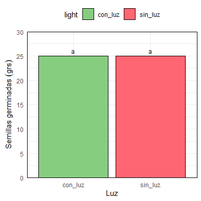

Figura 1. La germinación fue al 100% para ambos tratamientos.

A los 3 días se tiene una germinación casi al 100% para ambos tratamientos. Además se observa que con luz al 3 día hubo mayor germinación que sin luz.

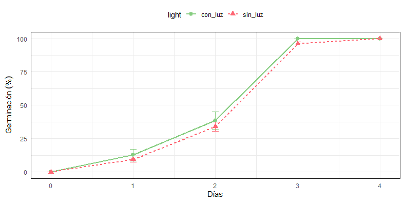

Figura 2. A partir del 2 y 3 día hubo una mayor germinación.

## 3.2 Tiempo medio de germinabilidad (mgt)

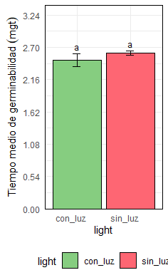

Figura 3. Tiempo medio de germinabilidad no se encuentran diferencias significativas.

## 3.3 velocidad de germinación (gsp)

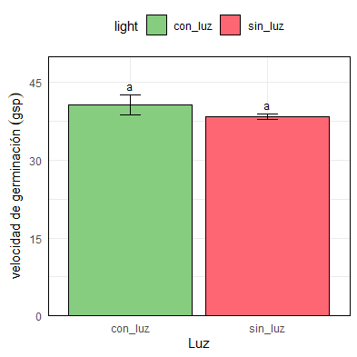

Figura 4. El tratamiento con luz tiene mayor respuesta a velocidad de germinación pero aun asi no existen diferencias signitivas.

## 3.4 Variación de la germinación (vgt)

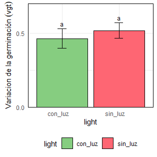

Figura 5. El tratamiento sin luz tiene mayor respuesta pero no hay diferencias significativas con el tratamiento con luz.

# 4 Discusión

En cuanto a la velocidad de germinación, la luz pareció tener un pequeño efecto, con un aumento en la velocidad en el tratamiento con luz. Sin embargo, la diferencia no fue significativa (p = 0.293). Este resultado es consistente con estudios como el de Bewley et al. (2013), quienes indican que la velocidad de germinación puede ser influenciada por diversos factores, pero no necesariamente de manera directa por la luz. Es importante señalar que la velocidad de germinación también depende de la calidad de la semilla, la temperatura, y la disponibilidad de agua, aspectos que probablemente jugaron un rol más relevante en este experimento.

La variación en la germinación, que refleja la dispersión en los tiempos de germinación, tampoco mostró diferencias significativas entre los tratamientos (p = 0.529). Este hallazgo coincide con estudios previos que sugieren que la luz, en algunos casos, no afecta de manera significativa la uniformidad de la germinación, especialmente si las condiciones de humedad y temperatura son constantes (Baskin & Baskin, 2014). De acuerdo con Gutterman (2002), la variación en la germinación también puede depender de la genética de las semillas y de factores ambientales más allá de la luz.

# 5 Conclusión

Los resultados de este estudio indican que la luz no tiene un efecto significativo sobre la germinación de las semillas en cuanto a la cantidad de semillas germinadas, el tiempo medio de germinabilidad, la velocidad de germinación, ni la variación de la germinación. A pesar de que ciertos parámetros mostraron ligeras diferencias entre los tratamientos con y sin luz, estos no fueron estadísticamente significativos, lo que sugiere que bajo las condiciones evaluadas, la luz no es un factor determinante en el proceso de germinación de las semillas. Este hallazgo podría ser relevante para comprender las condiciones óptimas para la germinación de semillas en experimentos controlados, sugiriendo que factores adicionales podrían tener un mayor impacto en este proceso.

# 6 Referencias bibliograficas

Baskin, C. C., & Baskin, J. M. (2000). Seeds: ecology, biogeography, and, evolution of dormancy and germination. Academic press.

Finch-Savage, B. (2013). Seeds: Physiology of development, germination and dormancy -JD Bewley, KJ Bradford, HWM Hilhorst H. Nonogaki. 392 pp. Springer, New York–Heidelberg–Dordrecht–London2013978-1-4614-4692-7. Seed Science Research, 23(4), 289-289.

Finch-Savage, W. E., & Leubner-Metzger, G. (2006). Seed dormancy and the control of germination. New Phytologist, 171(3), 501-523. https://doi.org/10.1111/j.1469-8137.2006.01787.x

Ghaleb, W., Ahmed, L. Q., Wagner, M.-H., Eprinchard-Ciesla, A., Olivares-Rodríguez, W. E., Perrot, C., Chenu, K., Norton, M., & Escobar-Gutiérrez, A. J. (2022). The Concepts of Seed Germination Rate and Germinability: A Re-Evaluation for Cool-Season Grasses. Agronomy, 12(6), Article 6. https://doi.org/10.3390/agronomy12061291 Gutterman, Y. (2002). Seed Germination: Theory and Practice.

Karssen, C. M. (1995). Seed Dormancy and Germination in Plants.

Lozano-Isla, Flavio; Benites-Alfaro, Omar Eduardo; Pompelli, Marcelo Francisco (2019). GerminaR: An R package for germination analysis with the interactive web application “GerminaQuant for R.” Ecological Research, 34(2), 339–346. https://doi.org/10.1111/1440-1703.1275

Smýkal, P., Aubert, G., Burstin, J., Coyne, C. J., Ellis, N. T. H., Flavell, A. J., Ford, R., Hýbl, M., Macas, J., Neumann, P., McPhee, K. E., Redden, R. J., Rubiales, D., Weller, J. L., & Warkentin, T. D. (2012). Pea (Pisum sativum L.) in the Genomic Era. Agronomy, 2(2), Article 2. https://doi.org/10.3390/agronomy2020074